# Risk Factor Analysis

## Outcome Variable

**Outcome Variable:** stunted

## Predictor Variables

**Intervention Variable:** predexfd6

**Adjustment Set:**

unadjusted

## Stratifying Variables

The analysis was stratified on these variable(s):

- agecat
- studyid
- country

## Data Summary

| agecat | studyid | country | predexfd6 | stunted | n_cell | n |
| --- | --- | --- | --- | --- | --- | --- |
| Birth | ki0047075b-MAL-ED | BANGLADESH | 0 | 0 | 91 | 231 |
| Birth | ki0047075b-MAL-ED | BANGLADESH | 0 | 1 | 21 | 231 |
| Birth | ki0047075b-MAL-ED | BANGLADESH | 1 | 0 | 101 | 231 |
| Birth | ki0047075b-MAL-ED | BANGLADESH | 1 | 1 | 18 | 231 |
| Birth | ki0047075b-MAL-ED | BRAZIL | 0 | 0 | 134 | 175 |
| Birth | ki0047075b-MAL-ED | BRAZIL | 0 | 1 | 14 | 175 |
| Birth | ki0047075b-MAL-ED | BRAZIL | 1 | 0 | 24 | 175 |
| Birth | ki0047075b-MAL-ED | BRAZIL | 1 | 1 | 3 | 175 |
| Birth | ki0047075b-MAL-ED | INDIA | 0 | 0 | 149 | 190 |
| Birth | ki0047075b-MAL-ED | INDIA | 0 | 1 | 26 | 190 |
| Birth | ki0047075b-MAL-ED | INDIA | 1 | 0 | 10 | 190 |
| Birth | ki0047075b-MAL-ED | INDIA | 1 | 1 | 5 | 190 |
| Birth | ki0047075b-MAL-ED | NEPAL | 0 | 0 | 131 | 170 |
| Birth | ki0047075b-MAL-ED | NEPAL | 0 | 1 | 16 | 170 |
| Birth | ki0047075b-MAL-ED | NEPAL | 1 | 0 | 21 | 170 |
| Birth | ki0047075b-MAL-ED | NEPAL | 1 | 1 | 2 | 170 |
| Birth | ki0047075b-MAL-ED | PERU | 0 | 0 | 132 | 256 |
| Birth | ki0047075b-MAL-ED | PERU | 0 | 1 | 18 | 256 |
| Birth | ki0047075b-MAL-ED | PERU | 1 | 0 | 95 | 256 |
| Birth | ki0047075b-MAL-ED | PERU | 1 | 1 | 11 | 256 |
| Birth | ki0047075b-MAL-ED | SOUTH AFRICA | 0 | 0 | 188 | 211 |
| Birth | ki0047075b-MAL-ED | SOUTH AFRICA | 0 | 1 | 20 | 211 |
| Birth | ki0047075b-MAL-ED | SOUTH AFRICA | 1 | 0 | 1 | 211 |
| Birth | ki0047075b-MAL-ED | SOUTH AFRICA | 1 | 1 | 2 | 211 |
| Birth | ki0047075b-MAL-ED | TANZANIA, UNITED REPUBLIC OF | 0 | 0 | 102 | 119 |
| Birth | ki0047075b-MAL-ED | TANZANIA, UNITED REPUBLIC OF | 0 | 1 | 16 | 119 |
| Birth | ki0047075b-MAL-ED | TANZANIA, UNITED REPUBLIC OF | 1 | 0 | 1 | 119 |
| Birth | ki0047075b-MAL-ED | TANZANIA, UNITED REPUBLIC OF | 1 | 1 | 0 | 119 |
| Birth | ki1000108-CMC-V-BCS-2002 | INDIA | 0 | 0 | 0 | 7 |
| Birth | ki1000108-CMC-V-BCS-2002 | INDIA | 0 | 1 | 0 | 7 |

[output cut: 158 more lines]

The following strata were considered:

- agecat: 24 months, studyid: ki0047075b-MAL-ED, country: BANGLADESH
- agecat: 24 months, studyid: ki0047075b-MAL-ED, country: BRAZIL
- agecat: 24 months, studyid: ki0047075b-MAL-ED, country: INDIA
- agecat: 24 months, studyid: ki0047075b-MAL-ED, country: NEPAL
- agecat: 24 months, studyid: ki0047075b-MAL-ED, country: PERU
- agecat: 24 months, studyid: ki0047075b-MAL-ED, country: SOUTH AFRICA
- agecat: 24 months, studyid: ki0047075b-MAL-ED, country: TANZANIA, UNITED REPUBLIC OF
- agecat: 24 months, studyid: ki1000108-CMC-V-BCS-2002, country: INDIA
- agecat: 24 months, studyid: ki1000108-IRC, country: INDIA
- agecat: 24 months, studyid: ki1017093b-PROVIDE, country: BANGLADESH
- agecat: 24 months, studyid: ki1101329-Keneba, country: GAMBIA
- agecat: 24 months, studyid: ki1113344-GMS-Nepal, country: NEPAL
- agecat: 24 months, studyid: ki1148112-LCNI-5, country: MALAWI
- agecat: 24 months, studyid: kiGH5241-JiVitA-3, country: BANGLADESH
- agecat: 24 months, studyid: kiGH5241-JiVitA-4, country: BANGLADESH
- agecat: 6 months, studyid: ki0047075b-MAL-ED, country: BANGLADESH
- agecat: 6 months, studyid: ki0047075b-MAL-ED, country: BRAZIL
- agecat: 6 months, studyid: ki0047075b-MAL-ED, country: INDIA
- agecat: 6 months, studyid: ki0047075b-MAL-ED, country: NEPAL
- agecat: 6 months, studyid: ki0047075b-MAL-ED, country: PERU
- agecat: 6 months, studyid: ki0047075b-MAL-ED, country: SOUTH AFRICA
- agecat: 6 months, studyid: ki0047075b-MAL-ED, country: TANZANIA, UNITED REPUBLIC OF
- agecat: 6 months, studyid: ki1000108-CMC-V-BCS-2002, country: INDIA
- agecat: 6 months, studyid: ki1000108-IRC, country: INDIA
- agecat: 6 months, studyid: ki1000109-EE, country: PAKISTAN
- agecat: 6 months, studyid: ki1000304b-SAS-CompFeed, country: INDIA
- agecat: 6 months, studyid: ki1000304b-SAS-FoodSuppl, country: INDIA
- agecat: 6 months, studyid: ki1017093b-PROVIDE, country: BANGLADESH
- agecat: 6 months, studyid: ki1101329-Keneba, country: GAMBIA
- agecat: 6 months, studyid: ki1113344-GMS-Nepal, country: NEPAL
- agecat: 6 months, studyid: ki1148112-LCNI-5, country: MALAWI
- agecat: 6 months, studyid: kiGH5241-JiVitA-3, country: BANGLADESH
- agecat: 6 months, studyid: kiGH5241-JiVitA-4, country: BANGLADESH
- agecat: Birth, studyid: ki0047075b-MAL-ED, country: BANGLADESH
- agecat: Birth, studyid: ki0047075b-MAL-ED, country: BRAZIL
- agecat: Birth, studyid: ki0047075b-MAL-ED, country: INDIA
- agecat: Birth, studyid: ki0047075b-MAL-ED, country: NEPAL
- agecat: Birth, studyid: ki0047075b-MAL-ED, country: PERU
- agecat: Birth, studyid: ki0047075b-MAL-ED, country: SOUTH AFRICA
- agecat: Birth, studyid: ki0047075b-MAL-ED, country: TANZANIA, UNITED REPUBLIC OF
- agecat: Birth, studyid: ki1000108-CMC-V-BCS-2002, country: INDIA
- agecat: Birth, studyid: ki1000108-IRC, country: INDIA
- agecat: Birth, studyid: ki1000109-EE, country: PAKISTAN
- agecat: Birth, studyid: ki1000304b-SAS-CompFeed, country: INDIA
- agecat: Birth, studyid: ki1101329-Keneba, country: GAMBIA
- agecat: Birth, studyid: kiGH5241-JiVitA-3, country: BANGLADESH
- agecat: Birth, studyid: kiGH5241-JiVitA-4, country: BANGLADESH

### Dropped Strata

Some strata were dropped due to rare outcomes:

- agecat: Birth, studyid: ki0047075b-MAL-ED, country: BRAZIL
- agecat: Birth, studyid: ki0047075b-MAL-ED, country: NEPAL
- agecat: Birth, studyid: ki0047075b-MAL-ED, country: SOUTH AFRICA
- agecat: Birth, studyid: ki0047075b-MAL-ED, country: TANZANIA, UNITED REPUBLIC OF
- agecat: Birth, studyid: ki1000108-CMC-V-BCS-2002, country: INDIA
- agecat: Birth, studyid: ki1000108-IRC, country: INDIA
- agecat: Birth, studyid: ki1000109-EE, country: PAKISTAN
- agecat: Birth, studyid: ki1000304b-SAS-CompFeed, country: INDIA
- agecat: 6 months, studyid: ki0047075b-MAL-ED, country: BRAZIL
- agecat: 6 months, studyid: ki0047075b-MAL-ED, country: NEPAL
- agecat: 6 months, studyid: ki0047075b-MAL-ED, country: SOUTH AFRICA
- agecat: 6 months, studyid: ki0047075b-MAL-ED, country: TANZANIA, UNITED REPUBLIC OF
- agecat: 6 months, studyid: ki1000108-CMC-V-BCS-2002, country: INDIA
- agecat: 6 months, studyid: ki1000108-IRC, country: INDIA
- agecat: 6 months, studyid: ki1000304b-SAS-FoodSuppl, country: INDIA
- agecat: 24 months, studyid: ki0047075b-MAL-ED, country: BRAZIL
- agecat: 24 months, studyid: ki0047075b-MAL-ED, country: SOUTH AFRICA
- agecat: 24 months, studyid: ki0047075b-MAL-ED, country: TANZANIA, UNITED REPUBLIC OF
- agecat: 24 months, studyid: ki1000108-CMC-V-BCS-2002, country: INDIA
- agecat: 24 months, studyid: ki1000108-IRC, country: INDIA

## Methods Detail

We’re interested in the causal parameters $E[Y_a]$ for all values of $a \in \mathcal{A}$. These parameters represent the mean outcome if, possibly contrary to fact, we intervened to set all units to have $A=a$. Under the randomization and positivity assumptions, these are identified by the statistical parameters $\psi_a=E_W[E_{Y|A,W}(Y|A=a,W)]$. In addition, we’re interested in the mean of $Y$, $E[Y]$ under no intervention (the observed mean). We will estimate these parameters by using SuperLearner to fit the relevant likelihood factors – $E_{Y|A,W}(Y|A=a,W)$ and $p(A=a|W)$, and then updating our likelihood fit using a joint TMLE.

For unadjusted analyses ($W=\{\}$), initial likelihoods were estimated using Lrnr_glm to estimate the simple $E(Y|A)$ and Lrnr_mean to estimate $p(A)$. For adjusted analyses, a small library containing Lrnr_glmnet, Lrnr_xgboost, and Lrnr_mean was used.

Having estimated these parameters, we will then use the delta method to estimate relative risks and attributable risks relative to a prespecified baseline level of $A$.

# Results Detail

## Results Plots

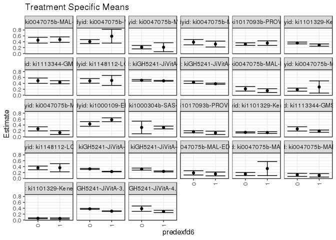

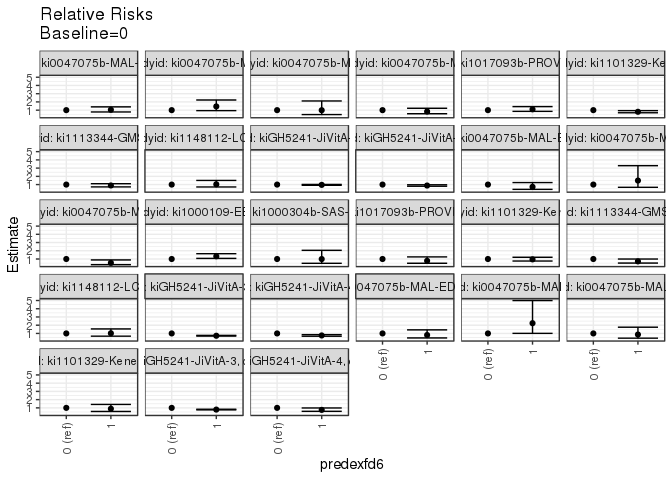

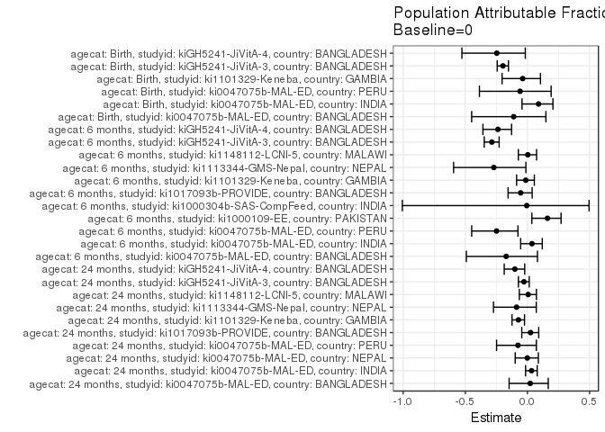

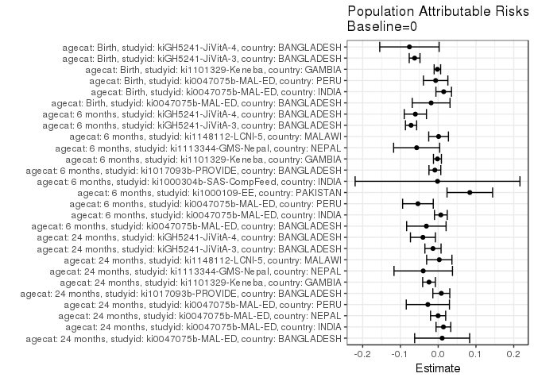

## Results Table

### Parameter: TSM

| agecat | studyid | country | intervention_level | baseline_level | estimate | ci_lower | ci_upper |
| --- | --- | --- | --- | --- | --- | --- | --- |
| Birth | ki0047075b-MAL-ED | BANGLADESH | 0 | NA | 0.1875000 | 0.1150575 | 0.2599425 |
| Birth | ki0047075b-MAL-ED | BANGLADESH | 1 | NA | 0.1512605 | 0.0867446 | 0.2157764 |
| Birth | ki0047075b-MAL-ED | INDIA | 0 | NA | 0.1485714 | 0.0957370 | 0.2014058 |
| Birth | ki0047075b-MAL-ED | INDIA | 1 | NA | 0.3333333 | 0.0941438 | 0.5725228 |
| Birth | ki0047075b-MAL-ED | PERU | 0 | NA | 0.1200000 | 0.0678944 | 0.1721056 |
| Birth | ki0047075b-MAL-ED | PERU | 1 | NA | 0.1037736 | 0.0456038 | 0.1619434 |
| Birth | ki1101329-Keneba | GAMBIA | 0 | NA | 0.0577972 | 0.0426879 | 0.0729065 |
| Birth | ki1101329-Keneba | GAMBIA | 1 | NA | 0.0516529 | 0.0319281 | 0.0713776 |
| Birth | kiGH5241-JiVitA-3 | BANGLADESH | 0 | NA | 0.3790768 | 0.3628748 | 0.3952788 |
| Birth | kiGH5241-JiVitA-3 | BANGLADESH | 1 | NA | 0.3001457 | 0.2917133 | 0.3085782 |
| Birth | kiGH5241-JiVitA-4 | BANGLADESH | 0 | NA | 0.3851351 | 0.2953625 | 0.4749077 |
| Birth | kiGH5241-JiVitA-4 | BANGLADESH | 1 | NA | 0.2907916 | 0.2512106 | 0.3303726 |
| 6 months | ki0047075b-MAL-ED | BANGLADESH | 0 | NA | 0.2142857 | 0.1381315 | 0.2904399 |
| 6 months | ki0047075b-MAL-ED | BANGLADESH | 1 | NA | 0.1544715 | 0.0904671 | 0.2184760 |
| 6 months | ki0047075b-MAL-ED | INDIA | 0 | NA | 0.1869159 | 0.1345715 | 0.2392603 |
| 6 months | ki0047075b-MAL-ED | INDIA | 1 | NA | 0.2777778 | 0.0704135 | 0.4851421 |
| 6 months | ki0047075b-MAL-ED | PERU | 0 | NA | 0.2692308 | 0.1994964 | 0.3389652 |
| 6 months | ki0047075b-MAL-ED | PERU | 1 | NA | 0.1415929 | 0.0771930 | 0.2059928 |
| 6 months | ki1000109-EE | PAKISTAN | 0 | NA | 0.4350649 | 0.3566591 | 0.5134708 |
| 6 months | ki1000109-EE | PAKISTAN | 1 | NA | 0.5779817 | 0.5123328 | 0.6436305 |
| 6 months | ki1000304b-SAS-CompFeed | INDIA | 0 | NA | 0.3157895 | 0.1014523 | 0.5301266 |
| 6 months | ki1000304b-SAS-CompFeed | INDIA | 1 | NA | 0.3139842 | 0.2679102 | 0.3600581 |
| 6 months | ki1017093b-PROVIDE | BANGLADESH | 0 | NA | 0.1700224 | 0.1351683 | 0.2048764 |
| 6 months | ki1017093b-PROVIDE | BANGLADESH | 1 | NA | 0.1323529 | 0.0753510 | 0.1893549 |
| 6 months | ki1101329-Keneba | GAMBIA | 0 | NA | 0.1497731 | 0.1305319 | 0.1690142 |
| 6 months | ki1101329-Keneba | GAMBIA | 1 | NA | 0.1433447 | 0.1149651 | 0.1717244 |
| 6 months | ki1113344-GMS-Nepal | NEPAL | 0 | NA | 0.2676056 | 0.1947233 | 0.3404879 |
| 6 months | ki1113344-GMS-Nepal | NEPAL | 1 | NA | 0.1905941 | 0.1522592 | 0.2289289 |
| 6 months | ki1148112-LCNI-5 | MALAWI | 0 | NA | 0.3555556 | 0.2928937 | 0.4182174 |
| 6 months | ki1148112-LCNI-5 | MALAWI | 1 | NA | 0.3617021 | 0.2240807 | 0.4993236 |
| 6 months | kiGH5241-JiVitA-3 | BANGLADESH | 0 | NA | 0.3226366 | 0.3056195 | 0.3396537 |
| 6 months | kiGH5241-JiVitA-3 | BANGLADESH | 1 | NA | 0.2320200 | 0.2230149 | 0.2410250 |
| 6 months | kiGH5241-JiVitA-4 | BANGLADESH | 0 | NA | 0.3149946 | 0.2808100 | 0.3491792 |
| 6 months | kiGH5241-JiVitA-4 | BANGLADESH | 1 | NA | 0.2376951 | 0.2213000 | 0.2540901 |
| 24 months | ki0047075b-MAL-ED | BANGLADESH | 0 | NA | 0.4536082 | 0.3542975 | 0.5529190 |
| 24 months | ki0047075b-MAL-ED | BANGLADESH | 1 | NA | 0.4732143 | 0.3805257 | 0.5659029 |
| 24 months | ki0047075b-MAL-ED | INDIA | 0 | NA | 0.4057971 | 0.3387537 | 0.4728406 |
| 24 months | ki0047075b-MAL-ED | INDIA | 1 | NA | 0.5882353 | 0.3537610 | 0.8227096 |
| 24 months | ki0047075b-MAL-ED | NEPAL | 0 | NA | 0.2160804 | 0.1587713 | 0.2733895 |
| 24 months | ki0047075b-MAL-ED | NEPAL | 1 | NA | 0.2142857 | 0.0619658 | 0.3666056 |
| 24 months | ki0047075b-MAL-ED | PERU | 0 | NA | 0.3859649 | 0.2963737 | 0.4755562 |
| 24 months | ki0047075b-MAL-ED | PERU | 1 | NA | 0.3214286 | 0.2213023 | 0.4215548 |
| 24 months | ki1017093b-PROVIDE | BANGLADESH | 0 | NA | 0.3210162 | 0.2770039 | 0.3650285 |
| 24 months | ki1017093b-PROVIDE | BANGLADESH | 1 | NA | 0.3541667 | 0.2759845 | 0.4323488 |
| 24 months | ki1101329-Keneba | GAMBIA | 0 | NA | 0.3587174 | 0.3289510 | 0.3884839 |
| 24 months | ki1101329-Keneba | GAMBIA | 1 | NA | 0.2873786 | 0.2482815 | 0.3264758 |
| 24 months | ki1113344-GMS-Nepal | NEPAL | 0 | NA | 0.4916667 | 0.4021261 | 0.5812073 |
| 24 months | ki1113344-GMS-Nepal | NEPAL | 1 | NA | 0.4388889 | 0.3875731 | 0.4902047 |
| 24 months | ki1148112-LCNI-5 | MALAWI | 0 | NA | 0.4838710 | 0.4049889 | 0.5627530 |
| 24 months | ki1148112-LCNI-5 | MALAWI | 1 | NA | 0.5000000 | 0.3314881 | 0.6685119 |
| 24 months | kiGH5241-JiVitA-3 | BANGLADESH | 0 | NA | 0.5045576 | 0.4794392 | 0.5296761 |
| 24 months | kiGH5241-JiVitA-3 | BANGLADESH | 1 | NA | 0.4868953 | 0.4724405 | 0.5013501 |
| 24 months | kiGH5241-JiVitA-4 | BANGLADESH | 0 | NA | 0.4395480 | 0.4000622 | 0.4790338 |
| 24 months | kiGH5241-JiVitA-4 | BANGLADESH | 1 | NA | 0.3882639 | 0.3685856 | 0.4079422 |

### Parameter: E(Y)

| agecat | studyid | country | intervention_level | baseline_level | estimate | ci_lower | ci_upper |
| --- | --- | --- | --- | --- | --- | --- | --- |
| Birth | ki0047075b-MAL-ED | BANGLADESH | NA | NA | 0.1688312 | 0.1204189 | 0.2172434 |
| Birth | ki0047075b-MAL-ED | INDIA | NA | NA | 0.1631579 | 0.1104782 | 0.2158376 |
| Birth | ki0047075b-MAL-ED | PERU | NA | NA | 0.1132813 | 0.0743812 | 0.1521813 |
| Birth | ki1101329-Keneba | GAMBIA | NA | NA | 0.0556745 | 0.0436637 | 0.0676854 |
| Birth | kiGH5241-JiVitA-3 | BANGLADESH | NA | NA | 0.3166335 | 0.3090239 | 0.3242430 |
| Birth | kiGH5241-JiVitA-4 | BANGLADESH | NA | NA | 0.3089961 | 0.2722361 | 0.3457561 |
| 6 months | ki0047075b-MAL-ED | BANGLADESH | NA | NA | 0.1829787 | 0.1334386 | 0.2325189 |
| 6 months | ki0047075b-MAL-ED | INDIA | NA | NA | 0.1939655 | 0.1429760 | 0.2449551 |
| 6 months | ki0047075b-MAL-ED | PERU | NA | NA | 0.2156134 | 0.1663773 | 0.2648495 |
| 6 months | ki1000109-EE | PAKISTAN | NA | NA | 0.5188172 | 0.4679751 | 0.5696593 |
| 6 months | ki1000304b-SAS-CompFeed | INDIA | NA | NA | 0.3140704 | 0.2712850 | 0.3568557 |
| 6 months | ki1017093b-PROVIDE | BANGLADESH | NA | NA | 0.1612350 | 0.1313580 | 0.1911120 |
| 6 months | ki1101329-Keneba | GAMBIA | NA | NA | 0.1477987 | 0.1318701 | 0.1637274 |
| 6 months | ki1113344-GMS-Nepal | NEPAL | NA | NA | 0.2106227 | 0.1763897 | 0.2448557 |
| 6 months | ki1148112-LCNI-5 | MALAWI | NA | NA | 0.3566176 | 0.2995882 | 0.4136471 |
| 6 months | kiGH5241-JiVitA-3 | BANGLADESH | NA | NA | 0.2508093 | 0.2426385 | 0.2589801 |
| 6 months | kiGH5241-JiVitA-4 | BANGLADESH | NA | NA | 0.2545198 | 0.2394884 | 0.2695513 |
| 24 months | ki0047075b-MAL-ED | BANGLADESH | NA | NA | 0.4641148 | 0.3963405 | 0.5318891 |
| 24 months | ki0047075b-MAL-ED | INDIA | NA | NA | 0.4196429 | 0.3548715 | 0.4844143 |
| 24 months | ki0047075b-MAL-ED | NEPAL | NA | NA | 0.2158590 | 0.1622206 | 0.2694975 |
| 24 months | ki0047075b-MAL-ED | PERU | NA | NA | 0.3585859 | 0.2916158 | 0.4255559 |
| 24 months | ki1017093b-PROVIDE | BANGLADESH | NA | NA | 0.3292894 | 0.2909105 | 0.3676684 |
| 24 months | ki1101329-Keneba | GAMBIA | NA | NA | 0.3344349 | 0.3106543 | 0.3582155 |
| 24 months | ki1113344-GMS-Nepal | NEPAL | NA | NA | 0.4520833 | 0.4075129 | 0.4966538 |
| 24 months | ki1148112-LCNI-5 | MALAWI | NA | NA | 0.4867725 | 0.4153250 | 0.5582200 |
| 24 months | kiGH5241-JiVitA-3 | BANGLADESH | NA | NA | 0.4907516 | 0.4775997 | 0.5039035 |
| 24 months | kiGH5241-JiVitA-4 | BANGLADESH | NA | NA | 0.3991375 | 0.3806098 | 0.4176653 |

### Parameter: RR

| agecat | studyid | country | intervention_level | baseline_level | estimate | ci_lower | ci_upper |
| --- | --- | --- | --- | --- | --- | --- | --- |
| Birth | ki0047075b-MAL-ED | BANGLADESH | 0 | 0 | 1.0000000 | 1.0000000 | 1.0000000 |
| Birth | ki0047075b-MAL-ED | BANGLADESH | 1 | 0 | 0.8067227 | 0.4537220 | 1.4343618 |
| Birth | ki0047075b-MAL-ED | INDIA | 0 | 0 | 1.0000000 | 1.0000000 | 1.0000000 |
| Birth | ki0047075b-MAL-ED | INDIA | 1 | 0 | 2.2435897 | 1.0072492 | 4.9974675 |
| Birth | ki0047075b-MAL-ED | PERU | 0 | 0 | 1.0000000 | 1.0000000 | 1.0000000 |
| Birth | ki0047075b-MAL-ED | PERU | 1 | 0 | 0.8647799 | 0.4255681 | 1.7572845 |
| Birth | ki1101329-Keneba | GAMBIA | 0 | 0 | 1.0000000 | 1.0000000 | 1.0000000 |
| Birth | ki1101329-Keneba | GAMBIA | 1 | 0 | 0.8936925 | 0.5626071 | 1.4196164 |
| Birth | kiGH5241-JiVitA-3 | BANGLADESH | 0 | 0 | 1.0000000 | 1.0000000 | 1.0000000 |
| Birth | kiGH5241-JiVitA-3 | BANGLADESH | 1 | 0 | 0.7917809 | 0.7529206 | 0.8326468 |
| Birth | kiGH5241-JiVitA-4 | BANGLADESH | 0 | 0 | 1.0000000 | 1.0000000 | 1.0000000 |
| Birth | kiGH5241-JiVitA-4 | BANGLADESH | 1 | 0 | 0.7550378 | 0.5777689 | 0.9866959 |
| 6 months | ki0047075b-MAL-ED | BANGLADESH | 0 | 0 | 1.0000000 | 1.0000000 | 1.0000000 |
| 6 months | ki0047075b-MAL-ED | BANGLADESH | 1 | 0 | 0.7208672 | 0.4176229 | 1.2443033 |
| 6 months | ki0047075b-MAL-ED | INDIA | 0 | 0 | 1.0000000 | 1.0000000 | 1.0000000 |
| 6 months | ki0047075b-MAL-ED | INDIA | 1 | 0 | 1.4861111 | 0.6695514 | 3.2985161 |
| 6 months | ki0047075b-MAL-ED | PERU | 0 | 0 | 1.0000000 | 1.0000000 | 1.0000000 |
| 6 months | ki0047075b-MAL-ED | PERU | 1 | 0 | 0.5259166 | 0.3116053 | 0.8876235 |
| 6 months | ki1000109-EE | PAKISTAN | 0 | 0 | 1.0000000 | 1.0000000 | 1.0000000 |
| 6 months | ki1000109-EE | PAKISTAN | 1 | 0 | 1.3284951 | 1.0736062 | 1.6438983 |
| 6 months | ki1000304b-SAS-CompFeed | INDIA | 0 | 0 | 1.0000000 | 1.0000000 | 1.0000000 |
| 6 months | ki1000304b-SAS-CompFeed | INDIA | 1 | 0 | 0.9942832 | 0.4810773 | 2.0549693 |
| 6 months | ki1017093b-PROVIDE | BANGLADESH | 0 | 0 | 1.0000000 | 1.0000000 | 1.0000000 |
| 6 months | ki1017093b-PROVIDE | BANGLADESH | 1 | 0 | 0.7784443 | 0.4831451 | 1.2542308 |
| 6 months | ki1101329-Keneba | GAMBIA | 0 | 0 | 1.0000000 | 1.0000000 | 1.0000000 |
| 6 months | ki1101329-Keneba | GAMBIA | 1 | 0 | 0.9570793 | 0.7558748 | 1.2118420 |
| 6 months | ki1113344-GMS-Nepal | NEPAL | 0 | 0 | 1.0000000 | 1.0000000 | 1.0000000 |
| 6 months | ki1113344-GMS-Nepal | NEPAL | 1 | 0 | 0.7122199 | 0.5076630 | 0.9992007 |
| 6 months | ki1148112-LCNI-5 | MALAWI | 0 | 0 | 1.0000000 | 1.0000000 | 1.0000000 |
| 6 months | ki1148112-LCNI-5 | MALAWI | 1 | 0 | 1.0172872 | 0.6688622 | 1.5472145 |
| 6 months | kiGH5241-JiVitA-3 | BANGLADESH | 0 | 0 | 1.0000000 | 1.0000000 | 1.0000000 |
| 6 months | kiGH5241-JiVitA-3 | BANGLADESH | 1 | 0 | 0.7191372 | 0.6750464 | 0.7661076 |
| 6 months | kiGH5241-JiVitA-4 | BANGLADESH | 0 | 0 | 1.0000000 | 1.0000000 | 1.0000000 |
| 6 months | kiGH5241-JiVitA-4 | BANGLADESH | 1 | 0 | 0.7546005 | 0.6647947 | 0.8565379 |
| 24 months | ki0047075b-MAL-ED | BANGLADESH | 0 | 0 | 1.0000000 | 1.0000000 | 1.0000000 |
| 24 months | ki0047075b-MAL-ED | BANGLADESH | 1 | 0 | 1.0432224 | 0.7776720 | 1.3994498 |
| 24 months | ki0047075b-MAL-ED | INDIA | 0 | 0 | 1.0000000 | 1.0000000 | 1.0000000 |
| 24 months | ki0047075b-MAL-ED | INDIA | 1 | 0 | 1.4495798 | 0.9415618 | 2.2316981 |
| 24 months | ki0047075b-MAL-ED | NEPAL | 0 | 0 | 1.0000000 | 1.0000000 | 1.0000000 |
| 24 months | ki0047075b-MAL-ED | NEPAL | 1 | 0 | 0.9916944 | 0.4643883 | 2.1177486 |
| 24 months | ki0047075b-MAL-ED | PERU | 0 | 0 | 1.0000000 | 1.0000000 | 1.0000000 |
| 24 months | ki0047075b-MAL-ED | PERU | 1 | 0 | 0.8327922 | 0.5647061 | 1.2281483 |
| 24 months | ki1017093b-PROVIDE | BANGLADESH | 0 | 0 | 1.0000000 | 1.0000000 | 1.0000000 |
| 24 months | ki1017093b-PROVIDE | BANGLADESH | 1 | 0 | 1.1032674 | 0.8507945 | 1.4306615 |
| 24 months | ki1101329-Keneba | GAMBIA | 0 | 0 | 1.0000000 | 1.0000000 | 1.0000000 |
| 24 months | ki1101329-Keneba | GAMBIA | 1 | 0 | 0.8011282 | 0.6831156 | 0.9395282 |
| 24 months | ki1113344-GMS-Nepal | NEPAL | 0 | 0 | 1.0000000 | 1.0000000 | 1.0000000 |
| 24 months | ki1113344-GMS-Nepal | NEPAL | 1 | 0 | 0.8926554 | 0.7189426 | 1.1083411 |
| 24 months | ki1148112-LCNI-5 | MALAWI | 0 | 0 | 1.0000000 | 1.0000000 | 1.0000000 |
| 24 months | ki1148112-LCNI-5 | MALAWI | 1 | 0 | 1.0333333 | 0.7106383 | 1.5025615 |
| 24 months | kiGH5241-JiVitA-3 | BANGLADESH | 0 | 0 | 1.0000000 | 1.0000000 | 1.0000000 |
| 24 months | kiGH5241-JiVitA-3 | BANGLADESH | 1 | 0 | 0.9649944 | 0.9136673 | 1.0192049 |
| 24 months | kiGH5241-JiVitA-4 | BANGLADESH | 0 | 0 | 1.0000000 | 1.0000000 | 1.0000000 |
| 24 months | kiGH5241-JiVitA-4 | BANGLADESH | 1 | 0 | 0.8833253 | 0.8015108 | 0.9734911 |

### Parameter: PAR

| agecat | studyid | country | intervention_level | baseline_level | estimate | ci_lower | ci_upper |
| --- | --- | --- | --- | --- | --- | --- | --- |
| Birth | ki0047075b-MAL-ED | BANGLADESH | 0 | NA | -0.0186688 | -0.0686965 | 0.0313589 |
| Birth | ki0047075b-MAL-ED | INDIA | 0 | NA | 0.0145865 | -0.0060153 | 0.0351882 |
| Birth | ki0047075b-MAL-ED | PERU | 0 | NA | -0.0067187 | -0.0390695 | 0.0256320 |
| Birth | ki1101329-Keneba | GAMBIA | 0 | NA | -0.0021226 | -0.0107077 | 0.0064624 |
| Birth | kiGH5241-JiVitA-3 | BANGLADESH | 0 | NA | -0.0624433 | -0.0767083 | -0.0481783 |
| Birth | kiGH5241-JiVitA-4 | BANGLADESH | 0 | NA | -0.0761390 | -0.1547638 | 0.0024857 |
| 6 months | ki0047075b-MAL-ED | BANGLADESH | 0 | NA | -0.0313070 | -0.0835151 | 0.0209011 |
| 6 months | ki0047075b-MAL-ED | INDIA | 0 | NA | 0.0070496 | -0.0098371 | 0.0239364 |
| 6 months | ki0047075b-MAL-ED | PERU | 0 | NA | -0.0536174 | -0.0941988 | -0.0130359 |
| 6 months | ki1000109-EE | PAKISTAN | 0 | NA | 0.0837523 | 0.0233987 | 0.1441058 |
| 6 months | ki1000304b-SAS-CompFeed | INDIA | 0 | NA | -0.0017191 | -0.2199177 | 0.2164795 |
| 6 months | ki1017093b-PROVIDE | BANGLADESH | 0 | NA | -0.0087874 | -0.0244270 | 0.0068522 |
| 6 months | ki1101329-Keneba | GAMBIA | 0 | NA | -0.0019743 | -0.0125058 | 0.0085571 |
| 6 months | ki1113344-GMS-Nepal | NEPAL | 0 | NA | -0.0569829 | -0.1179813 | 0.0040154 |
| 6 months | ki1148112-LCNI-5 | MALAWI | 0 | NA | 0.0010621 | -0.0250685 | 0.0271927 |
| 6 months | kiGH5241-JiVitA-3 | BANGLADESH | 0 | NA | -0.0718273 | -0.0866795 | -0.0569752 |
| 6 months | kiGH5241-JiVitA-4 | BANGLADESH | 0 | NA | -0.0604748 | -0.0898774 | -0.0310721 |
| 24 months | ki0047075b-MAL-ED | BANGLADESH | 0 | NA | 0.0105066 | -0.0623027 | 0.0833159 |
| 24 months | ki0047075b-MAL-ED | INDIA | 0 | NA | 0.0138458 | -0.0057185 | 0.0334100 |
| 24 months | ki0047075b-MAL-ED | NEPAL | 0 | NA | -0.0002214 | -0.0202957 | 0.0198530 |
| 24 months | ki0047075b-MAL-ED | PERU | 0 | NA | -0.0273791 | -0.0845528 | 0.0297947 |
| 24 months | ki1017093b-PROVIDE | BANGLADESH | 0 | NA | 0.0082733 | -0.0141483 | 0.0306948 |
| 24 months | ki1101329-Keneba | GAMBIA | 0 | NA | -0.0242825 | -0.0410951 | -0.0074699 |
| 24 months | ki1113344-GMS-Nepal | NEPAL | 0 | NA | -0.0395833 | -0.1170125 | 0.0378459 |
| 24 months | ki1148112-LCNI-5 | MALAWI | 0 | NA | 0.0029015 | -0.0305815 | 0.0363845 |
| 24 months | kiGH5241-JiVitA-3 | BANGLADESH | 0 | NA | -0.0138061 | -0.0352066 | 0.0075945 |
| 24 months | kiGH5241-JiVitA-4 | BANGLADESH | 0 | NA | -0.0404105 | -0.0734510 | -0.0073700 |

### Parameter: PAF

| agecat | studyid | country | intervention_level | baseline_level | estimate | ci_lower | ci_upper |
| --- | --- | --- | --- | --- | --- | --- | --- |
| Birth | ki0047075b-MAL-ED | BANGLADESH | 0 | NA | -0.1105769 | -0.4489721 | 0.1487889 |
| Birth | ki0047075b-MAL-ED | INDIA | 0 | NA | 0.0894009 | -0.0435793 | 0.2054358 |
| Birth | ki0047075b-MAL-ED | PERU | 0 | NA | -0.0593103 | -0.3863958 | 0.1906075 |
| Birth | ki1101329-Keneba | GAMBIA | 0 | NA | -0.0381260 | -0.2041448 | 0.1050033 |
| Birth | kiGH5241-JiVitA-3 | BANGLADESH | 0 | NA | -0.1972100 | -0.2433536 | -0.1527789 |
| Birth | kiGH5241-JiVitA-4 | BANGLADESH | 0 | NA | -0.2464078 | -0.5274925 | -0.0170475 |
| 6 months | ki0047075b-MAL-ED | BANGLADESH | 0 | NA | -0.1710963 | -0.4918946 | 0.0807215 |
| 6 months | ki0047075b-MAL-ED | INDIA | 0 | NA | 0.0363448 | -0.0544615 | 0.1193312 |
| 6 months | ki0047075b-MAL-ED | PERU | 0 | NA | -0.2486737 | -0.4486711 | -0.0762872 |
| 6 months | ki1000109-EE | PAKISTAN | 0 | NA | 0.1614292 | 0.0356493 | 0.2708037 |
| 6 months | ki1000304b-SAS-CompFeed | INDIA | 0 | NA | -0.0054737 | -1.0068383 | 0.4962338 |
| 6 months | ki1017093b-PROVIDE | BANGLADESH | 0 | NA | -0.0545005 | -0.1557574 | 0.0378853 |
| 6 months | ki1101329-Keneba | GAMBIA | 0 | NA | -0.0133582 | -0.0871685 | 0.0554409 |
| 6 months | ki1113344-GMS-Nepal | NEPAL | 0 | NA | -0.2705450 | -0.5944671 | -0.0124289 |
| 6 months | ki1148112-LCNI-5 | MALAWI | 0 | NA | 0.0029782 | -0.0730552 | 0.0736242 |
| 6 months | kiGH5241-JiVitA-3 | BANGLADESH | 0 | NA | -0.2863824 | -0.3476596 | -0.2278913 |
| 6 months | kiGH5241-JiVitA-4 | BANGLADESH | 0 | NA | -0.2376033 | -0.3582622 | -0.1276630 |
| 24 months | ki0047075b-MAL-ED | BANGLADESH | 0 | NA | 0.0226379 | -0.1475602 | 0.1675934 |
| 24 months | ki0047075b-MAL-ED | INDIA | 0 | NA | 0.0329941 | -0.0148853 | 0.0786148 |
| 24 months | ki0047075b-MAL-ED | NEPAL | 0 | NA | -0.0010255 | -0.0984795 | 0.0877826 |
| 24 months | ki0047075b-MAL-ED | PERU | 0 | NA | -0.0763529 | -0.2483603 | 0.0719542 |
| 24 months | ki1017093b-PROVIDE | BANGLADESH | 0 | NA | 0.0251246 | -0.0453975 | 0.0908893 |
| 24 months | ki1101329-Keneba | GAMBIA | 0 | NA | -0.0726077 | -0.1240977 | -0.0234762 |
| 24 months | ki1113344-GMS-Nepal | NEPAL | 0 | NA | -0.0875576 | -0.2732548 | 0.0710567 |
| 24 months | ki1148112-LCNI-5 | MALAWI | 0 | NA | 0.0059607 | -0.0652660 | 0.0724250 |
| 24 months | kiGH5241-JiVitA-3 | BANGLADESH | 0 | NA | -0.0281325 | -0.0726850 | 0.0145696 |
| 24 months | kiGH5241-JiVitA-4 | BANGLADESH | 0 | NA | -0.1012446 | -0.1868441 | -0.0218188 |